# FIT3181: Deep Learning (2022)

*CE/Lecturer:* Dr **Trung Le** | trunglm@monash.edu  
*Head Tutor:* Mr **Thanh Nguyen** | thanh.nguyen4@monash.edu  
Department of Data Science and AI, Faculty of Information Technology, Monash University, Australia

# Student Information

Surname: **Lim**  
Firstname: **Jessica**  
Student ID: **31954081**  
Email: **jlim0154@student.monash.edu**  
Your tutorial time: **Friday 2PM**

# Deep Neural Networks

### Due: 11:59pm Sunday, 18 September 2022 (Sunday)

#### Important note: This is an **individual** assignment. It contributes **20%** to your final mark. Read the assignment instruction carefully.

## Instruction

This notebook has been prepared for your to complete Assignment 1. The theme of this assignment is about practical machine learning knowledge and skills in deep neural networks, including feedforward and convolutional neural networks. Some sections have been partially completed to help you get started. **The total marks for this notebook is 100**.

- Before you start, read the entire notebook carefully once to understand what you need to do.
- For each cell marked with **#YOU ARE REQUIRED TO INSERT YOUR CODES IN THIS CELL**, there will be places where you **must** supply your own codes when instructed.

This assignment contains **three** parts:

- Part 1: Questions on theory and knowledge on machine learning and deep learning **[30 points], 30%**
- Part 2: Coding assessment on TensorFlow for Deep Neural Networks (DNN) **[30 points], 30%**
- Part 3: Coding assessment on TensorFlow for Convolution Neural Networks (CNN) **[40 points], 40%**

**Hint**: This assignment was essentially designed based on the lectures and tutorials sessions covered from Week 1 to Week 6. You are strongly recommended to go through these contents thoroughly which might help you to complete this assignment.

## What to submit

This assignment is to be completed individually and submitted to Moodle unit site. **By the due date, you are required to submit one single zip file, named xxx_assignment01_solution.zip where `xxx` is your student ID, to the corresponding Assignment (Dropbox) in Moodle**.

*For example, if your student ID is 12356, then gather all of your assignment solution to folder, create a zip file named 123456_assignment01_solution.zip and submit this file.*

Within this zip folder, you **must** submit the following files:

1. **Assignment01_solution.ipynb**: this is your Python notebook solution source file.
2. **Assignment01_output.html**: this is the output of your Python notebook solution *exported* in html format.
3. Any **extra files or folder** needed to complete your assignment (e.g., images used in your answers).

Since the notebook is quite big to load and work together, one recommended option is to split solution into three parts and work on them seperately. In that case, replace **Assignment01_solution.ipynb** by three notebooks: **Assignment01_Part1_solution.ipynb**, **Assignment01_Part2_solution.ipynb** and **Assignment01_Part3_solution.ipynb**

**You can run your codes on Google Colab. In this case, you need to capture the screenshots of your Google Colab model training and put in corresponding places in your Jupyter notebook. You also need to store your trained models to folder *./models* with recognizable file names (e.g., Part3_Sec3_2_model.h5).**

## Part 1: Theory and Knowledge Questions

[Total marks for this part: 30 points]

The first part of this assignment is for you to demonstrate your knowledge in deep learning that you have acquired from the lectures and tutorials materials. Most of the contents in this assignment are drawn from **the lectures and tutorials from weeks 1 to 3**. Going through these materials before attempting this part is highly recommended.

#### **Question 1.1** **Activation function plays an important role in modern Deep NNs. For each of the activation function below, state its output range, find its derivative (show your steps), and plot the activation fuction and its derivative**

**(a)** Leaky ReLU: $\text{LeakyReLU}\left(x\right)=\begin{cases} 0.01x & \text{if}\,x<0\\ x & \text{otherwise} \end{cases}$

[1.5 points]

**(b)** Softplus: $\text{Softplus}\left(x\right)=\text{ln}\left(1+e^{x}\right)$

[1.5 points]

**Numpy is possibly being used in the following questions. You need to import numpy here.**

```python
import numpy as np
#https://kawahara.ca/what-is-the-derivative-of-relu/#:~:text=The%20derivative%20of%20ReLU%20is%3A%20f%20%E2%80%B2%20%28x%29,x%20%3E%200%200%2C%20otherwise%20%2Fend%20short%20summary
#a
def LeakyRelu(x):
    "ReLu returns 0.01x if x>0, else x"
    #data = [0.01*x if x > 0 else x for value in x]
    #return np.array(data, dtype=float)
    #return np.maximum(0,x)
    return np.where(x > 0, x, x * 0.01)

#b
def Softplus(x):
    return np.log1p(np.exp(x))
    #return (np.exp(x.T)/np.sum(np.exp(x.T))).T
```

#### **Question 1.2** **Assume that we feed a data point $x$ with a ground-truth label $y=2$ to the feed-forward neural network with the ReLU activation function as shown in the following figure**

[figure not shown]

https://towardsdatascience.com/forward-propagation-in-neural-networks-simplified-math-and-code-version-bbcfef6f9250

**(a)** What is the numerical value of the latent presentation $h^1(x)$?

[1 point]

**(b)** What is the numerical value of the latent presentation $h^2(x)$?

[1 point]

**(c)** What is the numerical value of the logit $h^3(x)$?

[1 point]

**(d)** What is the corresonding prediction probabilities $p(x)$?

[1 point]

**(e)** What is the cross-entropy loss caused by the feed-forward neural network at $(x,y)$? Remind that $y=2$.

[1 point]

**(e)** Assume that we are applying the label smoothing technique (i.e., [link for main paper](https://papers.nips.cc/paper/2019/file/f1748d6b0fd9d439f71450117eba2725-Paper.pdf) from Goeff Hinton) with $\alpha = 0.1$. What is the relevant loss caused by the feed-forward neural network at $(x,y)$?

[1 point]

**You need to show both formulas and numerical results for earning full mark. Although it is optional, it is great if you show your numpy code for your computation.**

```python
def relu(x):
    return np.maximum(0,x)

#b
def softmax(x):
    return (np.exp(x.T)/np.sum(np.exp(x.T))).T


x = np.array([[1],[-1],[1]])
y = 2

w1 = np.array([[1, -1, 1],[1, -1, -1],[2, -1, 2],[-1, -2, 1]])
b1 = np.array([[1,0,1,0]]).T

w2 = np.array([[1, -1, -1, 2],[1, -1, 1, -1],[ -1, 2, -1, 2]])
b2 = np.array([[1,1,0]]).T

w3 = np.array([[1, -2, 1],[1, 2, -1],[-1, 1, -1]])
b3 = np.array([[0,0,0]]).T

#A
h1 = relu((w1@x)+b1)
print("h1 : " + str(h1))

#B
h2 = relu((w2@h1)+b2)
print("h2 : " + str(h2))

#C
h3 = relu((w3@h2)+b3)
print("h3 : " + str(h3))

#D
p = softmax(h3)
print("p : " + str(p))

#E
ce = -np.log(p[y-1,0])
print(" Cross-entropy : " + str(ce))
```

```
h1 : [[4]
 [1]
 [6]
 [2]]
h2 : [[2]
 [8]
 [0]]
h3 : [[ 0]
 [18]
 [ 6]]
p : [[1.52298859e-08]
 [9.99993841e-01]
 [6.14417451e-06]]
 Cross-entropy : 6.1594233637325895e-06
```

#### **Question 1.3** **Assume that we are constructing a multilayered feed-forward neural network for a classification problem with three classes where the model parameters will be generated randomly using your student ID. The architecture of this network is ($3 (Input)\rightarrow4(LeakyReLU)\rightarrow 3(Output)$) as shown in the following figure. Note that the LeakyReLU has the same formula as the one in Q1.1.**

[figure not shown]

We feed a feature vector $x=\left[\begin{array}{ccc} 1 & -1 & 1.5\end{array}\right]^{T}$ with ground-truth label $y=3$ to the above network.

**You need to show both formulas, numerical results, and your numpy code for your computation for earning full marks.**

```python
#Code to generate random matrices and biases for W1, b1, W2, b2
import numpy as np
student_id = 31954081           #insert your student id here for example 1234
np.random.seed(student_id)
W1 = np.random.rand(4,3)
b1 = np.random.rand(4,1)
W2 = np.random.rand(3,4)
b2 = np.random.rand(3,1)
```

**Forward propagation**

[figure not shown]

**(a)** What is the value of $\bar{h}^{1}(x)$?

[1 point]

```python
x = np.array([1,-1,1.5]).T
y = 3

h1_bar = (W1@x)+b1
print("h1_bar : " + str(h1))
```

```
h1_bar : [[4]
 [1]
 [6]
 [2]]
```

**(b)** What is the value of $h^{1}(x)$?

[1 point]

```python
LeakyRelu(h1_bar)
print("h1 : " + str(h1))
```

```
h1 : [[4]
 [1]
 [6]
 [2]]
```

**(c)** What is the predicted value $\hat{y}$?

[1 point]

```python
h2 = (W2@h1) + b2
p = softmax(h2)
yhat = p[y-1,0]

print("yhat : " + str(yhat))
```

```
yhat : 0.07689846645306185
```

**(d)** Suppose that we use the cross-entropy (CE) loss. What is the value of the CE loss $l$?

[1 point]

```python
ce = -np.log(yhat)
print("cross-entropy : " + str(ce))
```

```
cross-entropy : 2.565269344762209
```

**Backward propagation**

**(e)** What are the derivatives $\frac{\partial l}{\partial h^{2}},\frac{\partial l}{\partial W^{2}}$, and $\frac{\partial l}{\partial b^{2}}$?

[6 points]

[figure not shown]

**(e)** What are the derivatives $\frac{\partial l}{\partial h^{2}},\frac{\partial l}{\partial W^{2}}$, and $\frac{\partial l}{\partial b^{2}}$?

[6 points]

```python
g2 = p.T
g2[0, y-1] -= 1

dl_dh2 = g2
print("dl_dh2 : " + str(dl_dh2))

dl_dw2 = g2.T@h1.T
print("dl_dw2 : " + str(dl_dw2))

dl_db2 = g2
print("dl_db2 : " + str(dl_db2))
```

```
dl_dh2 : [[ 0.92163893  0.00146261 -0.92310153]]
dl_dw2 : [[ 3.68655571e+00  9.21638927e-01  5.52983356e+00  1.84327785e+00]
 [ 5.85042627e-03  1.46260657e-03  8.77563941e-03  2.92521314e-03]
 [-3.69240613e+00 -9.23101534e-01 -5.53860920e+00 -1.84620307e+00]]
dl_db2 : [[ 0.92163893  0.00146261 -0.92310153]]
```

**(f)** What are the derivatives $\frac{\partial l}{\partial h^{1}}, \frac{\partial l}{\partial \bar{h}^{1}},\frac{\partial l}{\partial W^{1}}$, and $\frac{\partial l}{\partial b^{1}}$?

[6 points]

[figure not shown]

```python
g = g2@W2

dl_dh = g
print("dl_dh :" + str(dl_dh))

dhl_dhl_bar = np.diag(np.where(h1_bar.T>0,1,0.01)[0])

g_bar = g@dhl_dhl_bar

dl_dhl_bar = g_bar
print("dl_dhl_bar :" + str(dl_dhl_bar))

dl_dw = g_bar.T@x.T
print("dl_dw :" + str(dl_dw))

dl_db = g_bar
print("dl_db :" + str(dl_db))
```

```
dl_dh :[[-0.14327729 -0.1182884   0.26612153  0.65178047]]
dl_dhl_bar :[[-0.14327729 -0.1182884   0.26612153  0.65178047]]
```

[output not shown]

**SGD update**

**(g)** Assume that we use SGD with learning rate $\eta=0.01$ to update the model parameters. What are the values of $W^2, b^2$ and $W^1, b^1$ after updating?

[5 points]

[figure not shown]

*Show your fomular*

```python
learning_rate = 0.01

x = np.array([[1,-1,1.5]]).T
y = 3

W2 = W2 - (learning_rate*dl_dw2)
b2 = b2 - (learning_rate*dl_db2.T)
W1 = W1 - (learning_rate*dl_dw)
b1 = b1 - (learning_rate*dl_db.T)

print("w2 : " + str(w2))
print("b2 : " + str(b2))
print("w1 : " + str(w1))
print("b1 : " + str(b1))

h1_bar = (W1@x)+b1
h1 = LeakyRelu(h1_bar)

h2 = (W2@h1)+b2
p = softmax(h2)

yhat = p[y-1,0]

ceg = np.log(yhat)

print("cross-entropy : " + str(ce))
print("cross-entropy-g : " + str(ceg))
```

```
w2 : [[ 1 -1 -1  2]
 [ 1 -1  1 -1]
 [-1  2 -1  2]]
b2 : [[0.23390275]
 [0.33575011]
 [0.24567707]]
w1 : [[ 1 -1  1]
 [ 1 -1 -1]
 [ 2 -1  2]
 [-1 -2  1]]
b1 : [[0.99777033]
 [0.46594603]
 [0.41992336]
 [0.7771992 ]]
cross-entropy : 2.565269344762209
cross-entropy-g : -0.644467898776914
```

## Part 2: Deep Neural Networks (DNN)

[Total marks for this part: 30 points]

The first part of this assignment is for you to demonstrate your basis knowledge in deep learning that you have acquired from the lectures and tutorials materials. Most of the contents in this assignment are drawn from **the tutorials covered from weeks 1 to 4**. Going through these materials before attempting this assignment is highly recommended.

In the first part of this assignment, you are going to work with the **FashionMNIST** dataset for *image recognition task*. It has the exact same format as MNIST (70,000 grayscale images of 28 × 28 pixels each with 10 classes), but the images represent fashion items rather than handwritten digits, so each class is more diverse, and the problem is significantly more challenging than MNIST.

#### **Question 2.1**. Load the Fashion MNIST using Keras datasets

[5 points]

We first use keras incoporated in TensorFlow 2.x for loading the training and testing sets.

```python
import tensorflow as tf
from tensorflow import keras
import os
import numpy as np
from sklearn.datasets import load_svmlight_file
import scipy.io as sio
```

```python
tf.random.set_seed(31954081)
```

We first use keras datasets in TF 2.x to load Fashion MNIST dataset.

```python
fashion_mnist = keras.datasets.fashion_mnist
(X_train_full_img, y_train_full), (X_test_img, y_test) = fashion_mnist.load_data()

print('Train: X = ', X_train_full_img.shape)
print('Test: X = ', X_test_img.shape)
print(X_train_full_img)
print(y_train_full)
```

```
Train: X =  (60000, 28, 28)
Test: X =  (10000, 28, 28)
[[[0 0 0 ... 0 0 0]
  [0 0 0 ... 0 0 0]
  [0 0 0 ... 0 0 0]
  ...
  [0 0 0 ... 0 0 0]
  [0 0 0 ... 0 0 0]
  [0 0 0 ... 0 0 0]]

 [[0 0 0 ... 0 0 0]
  [0 0 0 ... 0 0 0]
  [0 0 0 ... 0 0 0]
  ...
  [0 0 0 ... 0 0 0]
  [0 0 0 ... 0 0 0]
  [0 0 0 ... 0 0 0]]

 [[0 0 0 ... 0 0 0]
  [0 0 0 ... 0 0 0]
  [0 0 0 ... 0 0 0]
  ...
  [0 0 0 ... 0 0 0]
  [0 0 0 ... 0 0 0]
  [0 0 0 ... 0 0 0]]

 ...

 [[0 0 0 ... 0 0 0]
  [0 0 0 ... 0 0 0]
  [0 0 0 ... 0 0 0]
  ...
  [0 0 0 ... 0 0 0]
  [0 0 0 ... 0 0 0]
  [0 0 0 ... 0 0 0]]

 [[0 0 0 ... 0 0 0]
  [0 0 0 ... 0 0 0]
  [0 0 0 ... 0 0 0]
  ...
  [0 0 0 ... 0 0 0]
  [0 0 0 ... 0 0 0]
  [0 0 0 ... 0 0 0]]

 [[0 0 0 ... 0 0 0]
  [0 0 0 ... 0 0 0]
  [0 0 0 ... 0 0 0]
  ...
  [0 0 0 ... 0 0 0]
  [0 0 0 ... 0 0 0]
  [0 0 0 ... 0 0 0]]]
[9 0 0 ... 3 0 5]
```

The shape of X_train_full_img is $(60000, 28, 28 )$ and that of X_test_img is $(10000, 28, 28)$. We next convert them to matrices of vectors and store in X_train_full and X_test.

```python
num_train = X_train_full_img.shape[0]
num_test = X_test_img.shape[0]
X_train_full = X_train_full_img.reshape(num_train, -1)
X_test = X_test_img.reshape(num_test, -1)
print(X_train_full.shape, y_train_full.shape)
print(X_test.shape, y_test.shape)
```

```
(60000, 784) (60000,)
(10000, 784) (10000,)
```

#### **Question 2.2**. Preprocess the dataset and split into training, validation, and testing datasets

[5 points]

You need to write the code to address the following requirements:

- Print out the dimensions of X_train_full and X_test
- Use $10 \%$ of X_train_full for validation and the rest of X_train_full for training. This splits X_train_full and y_train_full into X_train, y_train ($90 \%$) and X_valid, y_valid ($10 \%$).
- Finally, scale the pixels of X_train, X_valid, and X_test to $[0,1]$) (i.e., $X = X/255.0$).

You have now the separate training, validation, and testing sets for training your model.

```python
import math
from sklearn.model_selection import train_test_split
from sklearn import preprocessing

N = X_train_full.shape[0]
i = math.floor(0.9*N)
X_train, y_train = X_train_full[:i], y_train_full[:i]
X_valid, y_valid = X_train_full[i:], y_train_full[i:]
#X_train, X_valid, y_train, y_valid = train_test_split(X1, y1, test_size = float(valid_size)/(valid_size+ train_size))


#X_train, X_valid, X_test = NormalizeData(X_train), NormalizeData(X_valid), NormalizeData(X_test)
x_train, X_valid, X_test = X_train/255.0, X_valid/255.0, X_test/255.0
```

#### **Question 2.3**. Visualize some images in the training set with labels

[5 points]

You are required to write the code to show **random** $36$ images in X_train_full_img (which is an array of images) with labels as in the following figure. Note that the class names of Fashion MNIST are as follows

- "1:T-shirt/top", "2:Trouser", "3:Pullover", "4:Dress", "5:Coat", "6:Sandal", "7:Shirt", "8:Sneaker", "9:Bag", "10:Ankle boot"

[figure not shown]

```python
import matplotlib.pyplot as plt
%matplotlib inline
```

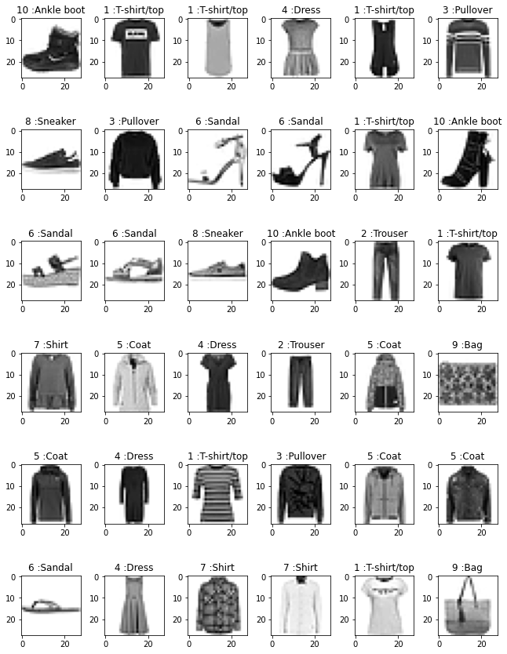

```python
# specify the number of rows and columns you want to see
num_row = 6
num_col = 6

# get a segment of the dataset
num = num_row*num_col
images = X_train_full_img[:num]
labels = y_train_full[:num]
desc = ["T-shirt/top","Trouser", "Pullover", "Dress", "Coat", "Sandal", "Shirt", "Sneaker", "Bag", "Ankle boot"]

# plot images
fig, axes = plt.subplots(num_row, num_col, figsize=(1.5*num_col,2*num_row))
for i in range(num_row*num_col):
    ax = axes[i//num_col, i%num_col]
    ax.imshow(images[i], cmap=plt.cm.binary)
    ax.set_title('{} :'.format(labels[i]+1)+ desc[labels[i]])
plt.tight_layout()
plt.show()
```

#### **Question 2.4**. Write code for the feed-forward neural net using TF 2.x

[5 points]

We now develop a feed-forward neural network with the architecture $784 \rightarrow 20(ReLU) \rightarrow 40(ReLU) \rightarrow 10(softmax)$. You can choose your own way to implement your network and an optimizer of interest. You should train model in $20$ epochs and evaluate the trained model on the test set.

```python
import tensorflow as tf
from tensorflow.keras.layers import Dense, Flatten
from tensorflow.keras.models import Sequential
```

```python
#train_size= int(X_train.shape[0])
#n_features= int(X_train.shape[1])
#n_classes= len(np.unique(y_train))
```

```python
dnn_model = Sequential() #based on the sequential we add dense layer and we can describe the input there and what activation function
dnn_model.add(Dense(units=20,  input_shape=(784,), activation='relu'))
dnn_model.add(Dense(units=40, activation='relu'))
dnn_model.add(Dense(units=10, activation='softmax'))
```

```python
dnn_model.build()
dnn_model.summary()
```

```
Model: "sequential"
_________________________________________________________________
Layer (type)                 Output Shape              Param #
=================================================================
dense (Dense)                (None, 20)                15700
_________________________________________________________________
dense_1 (Dense)              (None, 40)                840
_________________________________________________________________
dense_2 (Dense)              (None, 10)                410
=================================================================
Total params: 16,950
Trainable params: 16,950
Non-trainable params: 0
_________________________________________________________________
```

```python
dnn_model.layers
```

```
[<keras.layers.core.Dense at 0x1d7ad2d5e80>,
 <keras.layers.core.Dense at 0x1d7ace1eca0>,
 <keras.layers.core.Dense at 0x1d7aca8baf0>]
```

```python
hidden1 = dnn_model.layers[0]
hidden1
print(hidden1.name)
```

```
dense
```

```python
weights, biases = hidden1.get_weights()
```

```python
print(weights.shape)
print(biases.shape)
```

```
(784, 20)
(20,)
```

```python
dnn_model.compile(optimizer='adam',
                  loss='sparse_categorical_crossentropy',
                  metrics=['accuracy'])
```

```python
from tensorflow import keras
logdir = "tf_logs/"

# Init a tensorboard_callback
tensorboard_callback = keras.callbacks.TensorBoard(log_dir=logdir)

# Call the fit method, passing the tensorboard_callback
dnn_model.fit(x=X_train, y=y_train, batch_size=32, epochs=20, validation_data=(X_valid, y_valid), callbacks=[tensorboard_callback])
```

```
<keras.callbacks.History at 0x1d7b21cacd0>
```

#### **Question 2.5**. Tuning hyper-parameters with grid search

[5 points]

Assume that you need to tune the number of neurons on the first and second hidden layers $n_1 \in \{20, 40\}$, $n_2 \in \{20, 40\}$ and the used activation function $act \in \{sigmoid, tanh, relu\}$. The network has the architecture pattern $784 \rightarrow n_1 (act) \rightarrow n_2(act) \rightarrow 10(softmax)$ where $n_1, n_2$, and $act$ are in their grides. Write the code to tune the hyper-parameters $n_1, n_2$, and $act$. Note that you can freely choose the optimizer and learning rate of interest for this task.

```python
class MyDNN(tf.keras.Model):
    def __init__(self, n1, n2, act1, act2, n_classes= 10):
        super(MyDNN, self).__init__()
        self.n_classes = n_classes
        self.dense1 = tf.keras.layers.Dense(n1, input_shape =(784,), activation=act1)
        self.dense2 = tf.keras.layers.Dense(n2, activation= act2)
        self.dense3 = tf.keras.layers.Dense(self.n_classes, activation= 'softmax')


    def call(self,X): #X is the input, method call specifies how to compute the output from the input X
        h = self.dense1(X)
        h = self.dense2(h)
        h = self.dense3(h)
        return h
```

```python
lst_opts = [tf.keras.optimizers.Adam(), tf.keras.optimizers.RMSprop(), tf.keras.optimizers.SGD(momentum=0.2)]
lst_learning_rates = [0.1, 0.01, 0.001]
lst_n1 = [20,40]
lst_n2 = [20,40]
lst_act = ['sigmoid','tanh','relu']
best_acc= - np.inf
best_history = None
opt = tf.keras.optimizers.SGD(learning_rate=0.001)
best_n1 = None
best_n2 = None
best_act = None


for n1 in lst_n1:
    for n2 in lst_n2:
        for act1 in lst_act:
            for act2 in lst_act:
                for opt in lst_opts:
                    for lr in lst_learning_rates:
                        dnn = MyDNN(n1, n2, act1, act2, n_classes=10)
                        opt.learning_rate = lr
                        dnn.compile(optimizer=opt, loss='sparse_categorical_crossentropy', metrics=['accuracy'])
                        print("Training with optimizer = {}, learning rate = {}, n1 = {}, n2 rate = {}, act1 = {}, act2 = {}".format(opt.get_config()['name'], lr, n1, n2, act1 , act2))
                        #dnn.fit(x=X_train, y=y_train, batch_size=32, epochs=10, validation_data=(X_valid, y_valid), callbacks=[tensorboard_callback])
                        dnn.fit(X_train, y_train, batch_size=32, epochs=10, verbose=0)
                        valid_loss, valid_acc = dnn.evaluate(X_valid, y_valid)
                        #print('\tvalid acc = {}, valid loss = {}'.format(valid_acc, valid_loss))
                        if(valid_acc > best_acc):
                            best_acc = valid_acc
                            best_model = dnn
                            best_opt = opt
                            best_lr = lr
                            best_n1 = n1
                            best_n2 = n2
                            best_act1 = act1
                            best_act2 = act2

print('\nThe best model is with optimizer = {}, learning rate = {}'.format(best_opt.get_config()['name'], best_lr))
print("best n1 : " + str(best_n1) + ", best n2 = " + str(best_n2) + ", best act + " + str(best_act))
best_model.save('my_model', save_format='tf')
print('Saved the best model to hard disk')
```

```
Training with optimizer = Adam, learning rate = 0.1, n1 = 20, n2 rate = 20, act1 = sigmoid, act2 = sigmoid
Training with optimizer = Adam, learning rate = 0.01, n1 = 20, n2 rate = 20, act1 = sigmoid, act2 = sigmoid
Training with optimizer = Adam, learning rate = 0.001, n1 = 20, n2 rate = 20, act1 = sigmoid, act2 = sigmoid
Training with optimizer = RMSprop, learning rate = 0.1, n1 = 20, n2 rate = 20, act1 = sigmoid, act2 = sigmoid
Training with optimizer = RMSprop, learning rate = 0.01, n1 = 20, n2 rate = 20, act1 = sigmoid, act2 = sigmoid
Training with optimizer = RMSprop, learning rate = 0.001, n1 = 20, n2 rate = 20, act1 = sigmoid, act2 = sigmoid
Training with optimizer = SGD, learning rate = 0.1, n1 = 20, n2 rate = 20, act1 = sigmoid, act2 = sigmoid
Training with optimizer = SGD, learning rate = 0.01, n1 = 20, n2 rate = 20, act1 = sigmoid, act2 = sigmoid
Training with optimizer = SGD, learning rate = 0.001, n1 = 20, n2 rate = 20, act1 = sigmoid, act2 = sigmoid
Training with optimizer = Adam, learning rate = 0.1, n1 = 20, n2 rate = 20, act1 = sigmoid, act2 = tanh
Training with optimizer = Adam, learning rate = 0.01, n1 = 20, n2 rate = 20, act1 = sigmoid, act2 = tanh
Training with optimizer = Adam, learning rate = 0.001, n1 = 20, n2 rate = 20, act1 = sigmoid, act2 = tanh
Training with optimizer = RMSprop, learning rate = 0.1, n1 = 20, n2 rate = 20, act1 = sigmoid, act2 = tanh
Training with optimizer = RMSprop, learning rate = 0.01, n1 = 20, n2 rate = 20, act1 = sigmoid, act2 = tanh
Training with optimizer = RMSprop, learning rate = 0.001, n1 = 20, n2 rate = 20, act1 = sigmoid, act2 = tanh
Training with optimizer = SGD, learning rate = 0.1, n1 = 20, n2 rate = 20, act1 = sigmoid, act2 = tanh
Training with optimizer = SGD, learning rate = 0.01, n1 = 20, n2 rate = 20, act1 = sigmoid, act2 = tanh
Training with optimizer = SGD, learning rate = 0.001, n1 = 20, n2 rate = 20, act1 = sigmoid, act2 = tanh
Training with optimizer = Adam, learning rate = 0.1, n1 = 20, n2 rate = 20, act1 = sigmoid, act2 = relu
Training with optimizer = Adam, learning rate = 0.01, n1 = 20, n2 rate = 20, act1 = sigmoid, act2 = relu
Training with optimizer = Adam, learning rate = 0.001, n1 = 20, n2 rate = 20, act1 = sigmoid, act2 = relu
Training with optimizer = RMSprop, learning rate = 0.1, n1 = 20, n2 rate = 20, act1 = sigmoid, act2 = relu
Training with optimizer = RMSprop, learning rate = 0.01, n1 = 20, n2 rate = 20, act1 = sigmoid, act2 = relu
Training with optimizer = RMSprop, learning rate = 0.001, n1 = 20, n2 rate = 20, act1 = sigmoid, act2 = relu
Training with optimizer = SGD, learning rate = 0.1, n1 = 20, n2 rate = 20, act1 = sigmoid, act2 = relu
Training with optimizer = SGD, learning rate = 0.01, n1 = 20, n2 rate = 20, act1 = sigmoid, act2 = relu
Training with optimizer = SGD, learning rate = 0.001, n1 = 20, n2 rate = 20, act1 = sigmoid, act2 = relu
Training with optimizer = Adam, learning rate = 0.1, n1 = 20, n2 rate = 20, act1 = tanh, act2 = sigmoid
Training with optimizer = Adam, learning rate = 0.01, n1 = 20, n2 rate = 20, act1 = tanh, act2 = sigmoid
Training with optimizer = Adam, learning rate = 0.001, n1 = 20, n2 rate = 20, act1 = tanh, act2 = sigmoid
Training with optimizer = RMSprop, learning rate = 0.1, n1 = 20, n2 rate = 20, act1 = tanh, act2 = sigmoid
Training with optimizer = RMSprop, learning rate = 0.01, n1 = 20, n2 rate = 20, act1 = tanh, act2 = sigmoid
Training with optimizer = RMSprop, learning rate = 0.001, n1 = 20, n2 rate = 20, act1 = tanh, act2 = sigmoid
Training with optimizer = SGD, learning rate = 0.1, n1 = 20, n2 rate = 20, act1 = tanh, act2 = sigmoid
Training with optimizer = SGD, learning rate = 0.01, n1 = 20, n2 rate = 20, act1 = tanh, act2 = sigmoid
Training with optimizer = SGD, learning rate = 0.001, n1 = 20, n2 rate = 20, act1 = tanh, act2 = sigmoid
Training with optimizer = Adam, learning rate = 0.1, n1 = 20, n2 rate = 20, act1 = tanh, act2 = tanh
Training with optimizer = Adam, learning rate = 0.01, n1 = 20, n2 rate = 20, act1 = tanh, act2 = tanh
Training with optimizer = Adam, learning rate = 0.001, n1 = 20, n2 rate = 20, act1 = tanh, act2 = tanh
Training with optimizer = RMSprop, learning rate = 0.1, n1 = 20, n2 rate = 20, act1 = tanh, act2 = tanh
Training with optimizer = RMSprop, learning rate = 0.01, n1 = 20, n2 rate = 20, act1 = tanh, act2 = tanh
Training with optimizer = RMSprop, learning rate = 0.001, n1 = 20, n2 rate = 20, act1 = tanh, act2 = tanh
Training with optimizer = SGD, learning rate = 0.1, n1 = 20, n2 rate = 20, act1 = tanh, act2 = tanh
Training with optimizer = SGD, learning rate = 0.01, n1 = 20, n2 rate = 20, act1 = tanh, act2 = tanh
Training with optimizer = SGD, learning rate = 0.001, n1 = 20, n2 rate = 20, act1 = tanh, act2 = tanh
Training with optimizer = Adam, learning rate = 0.1, n1 = 20, n2 rate = 20, act1 = tanh, act2 = relu
Training with optimizer = Adam, learning rate = 0.01, n1 = 20, n2 rate = 20, act1 = tanh, act2 = relu
Training with optimizer = Adam, learning rate = 0.001, n1 = 20, n2 rate = 20, act1 = tanh, act2 = relu
Training with optimizer = RMSprop, learning rate = 0.1, n1 = 20, n2 rate = 20, act1 = tanh, act2 = relu
Training with optimizer = RMSprop, learning rate = 0.01, n1 = 20, n2 rate = 20, act1 = tanh, act2 = relu
Training with optimizer = RMSprop, learning rate = 0.001, n1 = 20, n2 rate = 20, act1 = tanh, act2 = relu
Training with optimizer = SGD, learning rate = 0.1, n1 = 20, n2 rate = 20, act1 = tanh, act2 = relu
Training with optimizer = SGD, learning rate = 0.01, n1 = 20, n2 rate = 20, act1 = tanh, act2 = relu
Training with optimizer = SGD, learning rate = 0.001, n1 = 20, n2 rate = 20, act1 = tanh, act2 = relu
Training with optimizer = Adam, learning rate = 0.1, n1 = 20, n2 rate = 20, act1 = relu, act2 = sigmoid
```

[output not shown]

[output cut: 29 more lines]

[output not shown]

```python
print('\nThe best model is with optimizer = {}, learning rate = {}'.format(best_opt.get_config()['name'], best_lr))
print("best n1 : " + str(best_n1) + ", best n2 = " + str(best_n2) + ", best act + " + str(best_act))
best_model.save('my_model', save_format='tf')
print('Saved the best model to hard disk')
```

[output not shown]

```python
restored_model = tf.keras.models.load_model('my_model')
print('Evaluating the best model on the test set')
_, test_acc= restored_model.evaluate(X_test, y_test)
print('Test acc= {}'.format(test_acc))
```

[output not shown]

```python
import pandas as pd

pd.DataFrame(best_history.history).plot(figsize=(8, 5))
plt.grid(True)
plt.xlabel("Epoch")
plt.gca().set_ylim(0, 1) # set the vertical range to [0-1]
plt.show()
```

[output not shown]

#### **Question 2.6**. Experimenting with **the label smoothing** technique

[5 points]

Implement the label smoothing technique (i.e., [link for main paper](https://papers.nips.cc/paper/2019/file/f1748d6b0fd9d439f71450117eba2725-Paper.pdf) from Goeff Hinton) by yourself. Note that you cannot use the built-in label-smoothing loss function in TF2.x. Try the label smoothing technique with $\alpha =0.1, 0.15, 0.2$ and report the performances. You need to examine the label smoothing technique with the best architecture obtained in **Question 2.5**.

```python
#Insert your code here. You can add more cells if necessary
import torch
import numpy as np
import torch.nn as nn
import torch.nn.functional as F
from torch.autograd import Variable
from torch.nn.modules.loss import _WeightedLoss

#y_ls = (1 - α) * y_hot + α / K #loss formulae
#∇CE = p - y = softmax(z) - y
#where cs(x) is the cross_entropyof x (i.e. - log(px)), and i is the correct class

class LabelSmoothingLoss(torch.nn.Module):
    def __init__(self, epsilon: float = 0.1,
                 reduction="mean", weight=None):
        super(LabelSmoothingLoss, self).__init__()
        self.epsilon   = epsilon
        self.reduction = reduction
        self.weight    = weight

    def reduce_loss(self, loss):
        return loss.mean() if self.reduction == 'mean' else loss.sum() \
         if self.reduction == 'sum' else loss

    def linear_combination(self, i, j):
        return (1 - self.epsilon) * i + self.epsilon * j

    def forward(self, predict_tensor, target):
        assert 0 <= self.epsilon < 1

        if self.weight is not None:
            self.weight = self.weight.to(predict_tensor.device)

        num_classes = predict_tensor.size(-1)

        log_preds = F.log_softmax(predict_tensor, dim=-1)

        loss = self.reduce_loss(-log_preds.sum(dim=-1))

        negative_log_likelihood_loss = F.nll_loss(
            log_preds, target, reduction=self.reduction, weight=self.weight
        )
        return self.linear_combination(negative_log_likelihood_loss, loss / num_classes,)
```

```python
ep = [0.1, 0.15, 0.2]

for eps in ep :
    loss_criterion = LabelSmoothingLoss(epsilon=eps)
    predict_tensor = torch.FloatTensor(restored_model.evaluate(X_test))
    target = Variable(torch.LongTensor(y_train)
    loss_label_smoothed = loss_criterion(restored_model.evaluate(y_test))
    print( "epsilon : {}, loss_label_smooth : {}.format(eps, loss_label_smoothed))
    torch.nn.CrossEntropyLoss(weight=None, size_average=None,
                          ignore_index=- 100, reduce=None,
                          reduction='mean', label_smoothing=eps)
```

[output not shown]

END OF PART 1 AND 2

GOOD LUCK WITH YOUR ASSIGNMENT 1!